# Reproducible Research: Course Project 1

Reading data, removing missing values and importing libraries

```r
library(ggplot2)
require(gridExtra)

data <- read.csv('activity.csv')
```

## Plotting histogram of steps per day and calculating mean and median steps per day

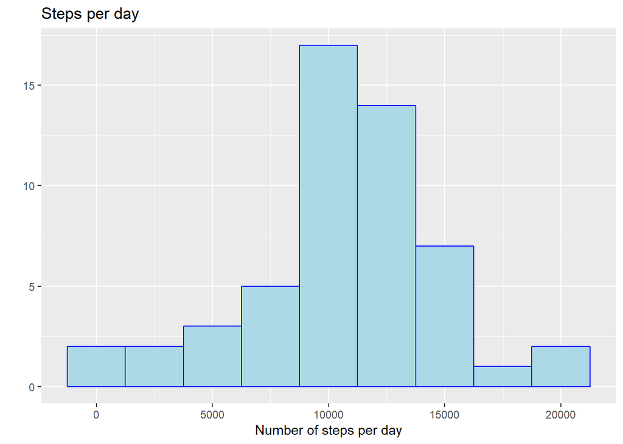

```r
steps_per_day <-aggregate(data$steps, by=list(data$date), FUN=sum)
mean_steps_per_day <- mean(steps_per_day$x, na.rm = TRUE)
median_steps_per_day <- median(steps_per_day$x, na.rm = TRUE)

q <- qplot(steps_per_day$x,
           main = 'Steps per day',
           xlab = 'Number of steps per day',
           geom = 'histogram',
           binwidth = 2500,
           col = I("blue"),
           fill = I("light blue"))
print(q)
```

Average number of steps per day: 10766.19

Median number of steps per day: 10765

## Average number of steps per 5 min interval and handling missing values:

Averaging number of steps every 5 min interval over all dates in the data set

```r
five_min_intervals <- aggregate(data$steps, by=list(data$interval), FUN=mean, na.rm=TRUE)
names(five_min_intervals) <- c("Interval", "Average number of steps")
```

Handling missing values by filling all occurances of NA in steps column with the average number of steps on the given 5 min interval, averaged over all dates in the data set

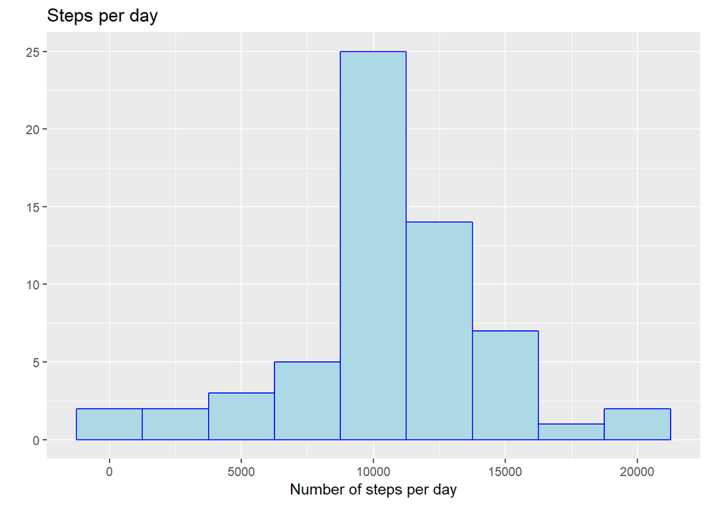

```r
missing_values <- sum(is.na(data))

for(i in unique(data$interval)){
  data_subsection <- data[data$interval == i, ]
  data_subsection$steps[is.na(data_subsection$steps)] <- floor(five_min_intervals$`Average number of steps`[five_min_intervals$Interval == i])
  data[data$interval == i, ] <- data_subsection
}


steps_per_day <-aggregate(data$steps, by=list(data$date), FUN=sum)
mean_steps_per_day <- mean(steps_per_day$x, na.rm = TRUE)
median_steps_per_day <- median(steps_per_day$x, na.rm = TRUE)

q <- qplot(steps_per_day$x,
           main = 'Steps per day',
           xlab = 'Number of steps per day',
           geom = 'histogram',
           binwidth = 2500,
           col = I("blue"),
           fill = I("light blue"))
print(q)
```

There are 2304 rows with missing data in the dataset. The new mean and median of the data set with the missing values replaced by averages are 10749.77 and 10641 respectively. The mean value is more or less the same as before, slightly lower, but the median has sunk by about a 100. It is clear from the two histogram that the one produced from the data set with the replaced missing values are sharper, it peaks higher.

Plotting a line plot over of the average number of steps in every 5 min interval (y-axis) agains the interval number (x-axis)

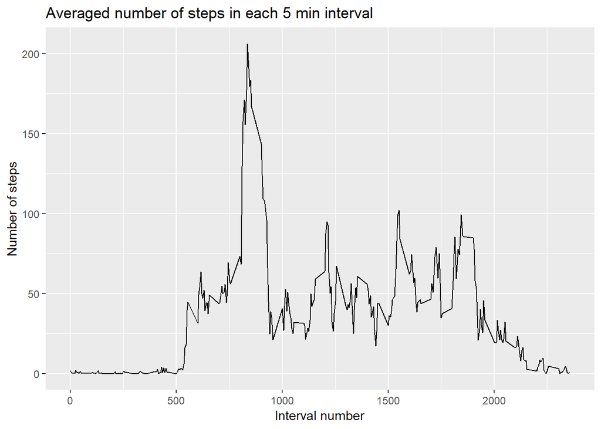

```r
q1 <- qplot(five_min_intervals$Interval, five_min_intervals$`Average number of steps`,
            xlab = 'Interval number',
            ylab = 'Number of steps',
            main = 'Averaged number of steps in each 5 min interval',
            geom  = 'line')
print(q1)
```

```r
interval_with_max_numer_of_steps <- max(five_min_intervals)
```

## Average number of steps per 5 minute interval during weekdays

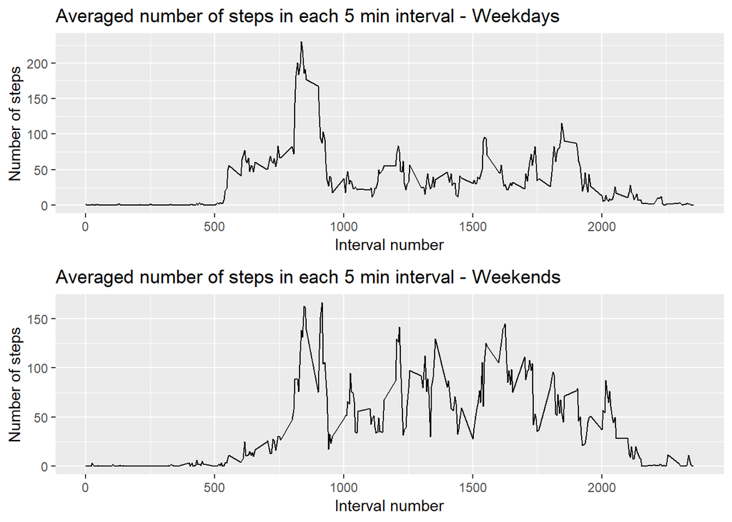

```r
data$weekend = chron::is.weekend(data$date)


weekday <- data[!data$weekend, ]
weekday <- aggregate(weekday$steps, by=list(weekday$interval), FUN=mean)
names(weekday) <- c("Interval", "Average number of steps")

q2 <- qplot(weekday$Interval, weekday$`Average number of steps`,
            xlab = 'Interval number',
            ylab = 'Number of steps',
            main = 'Averaged number of steps in each 5 min interval - Weekdays',
            geom = 'line')

weekend <- data[data$weekend, ]
weekend <- aggregate(weekend$steps, by=list(weekend$interval), FUN=mean)
names(weekend) <- c("Interval", "Average number of steps")

q3 <- qplot(weekend$Interval, weekend$`Average number of steps`,
            xlab='Interval number',
            ylab = 'Number of steps',
            main = 'Averaged number of steps in each 5 min interval - Weekends',
            geom = 'line')

q4 <- grid.arrange(q2, q3)
```

The activity pattern during weekends appear to be much more spread out across the day than during the weekdays. Weekdays have much more of a clear peak around the 800th 5-min interval